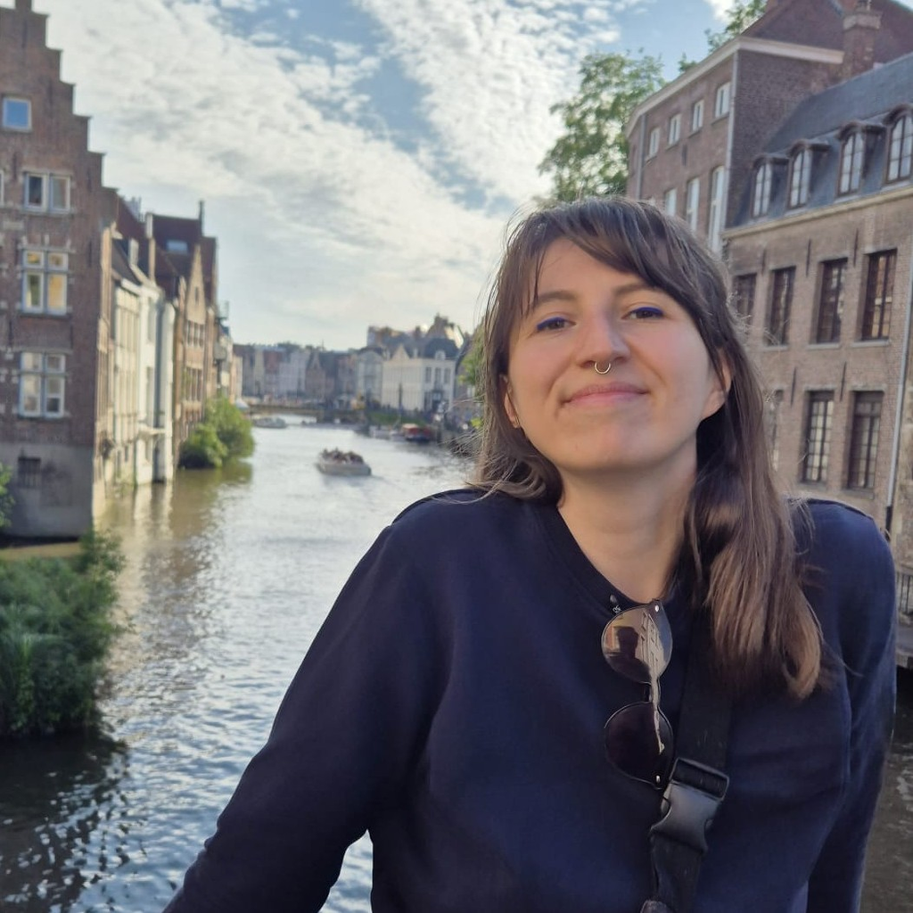

### Postdoc Researcher, Medical Neuroscience Department, Donders Institute, Radboud University Medical Center, Nijmegen

I am currently a postdoc at the Donders Institute in Andre Marquand’s group [Predictive Clinical Neuroscience Lab](https://predictiveclinicalneuroscience.com/) where I work on the [Precognition project](https://precognition-project.org/), looking at cognitive impairment as a predictor of schizophrenia.

**PhD research**  
I finished my PhD “Grey or white, does it matter? Integrating grey and white matter structural MRI metrics in developmental cognitive neuroscience” in Rogier Kievit group [Lifespan Cognitive Dynamics Lab](https://www.rogierkievit.com/) in March 2026. There, I studied the co-development of grey and white matter structures in adolescence.

My posters and talk slides are uploaded on [OSF](https://osf.io/ep2dg/). Feel free to contact me for information on any of these projects or for a collaboration.

**Future**  
I would like to pursue my career in academia and focus on intergenerational transmission of negative parenting and mental health issue. I am particularly interested in family models, but also on how genetics, environment and epigenetic interact together during development.

**On the side** Alongside my PhD, I am also invested in reducing the carbon footprint of academia, working both within [my department](https://www.linkedin.com/feed/update/urn:li:activity:7470105880110338048/) and the Organization for Human Brain Mapping, as the past chair of the [SEA-SIG](https://ohbm-environment.org/).